# 002 — Baseline classifiers (mlr3) on the labelled SNI feature matrix

Author

Dan MacLean

Published

April 23, 2026

## Goal

Quantify how well the canonical SNI features distinguish helper from sensor proteins on the 18-protein labelled benchmark, using an mlr3 pipeline under leave-one-out cross-validation (LOOCV). Three feature subsets — Scientist, Co-Scientist, and Combined — are evaluated under two strategies for the α1-NA features (drop them, or median-impute them). Observed LOOCV accuracies and AUCs are then compared against permutation null distributions obtained by re-running the same pipeline on label-shuffled data.

The idea here is that because we’re setting up an `mlr3` factory-style classifier pipeline, we can be maximalist about what sub-sets/super-sets to look at. We can therefore compare the Co and Scientist features at low effort and the effect of the missing value features.

We are optimistic for good classifiers because of the prevalance of single features that do excellent sensor/helper classification on there own.

## Hypotheses

1. Multiple single features already give perfect rank separation on this benchmark (notebook 001), so multivariate LOOCV accuracy will be at or near 1.0 for at least the Scientist and Combined subsets under either α1-policy.
2. The Scientist and Co-Scientist subsets, evaluated on the same 18 proteins, will give LOOCV scores that are not distinguishable from each other, since one misclassification at n = 18 corresponds to a change of 1/18 ≈ 0.056 in accuracy.
3. The permutation null distribution of LOOCV accuracy will be roughly centred on 0.5; empirical p-values for the observed scores will be bounded by 1 / (n_perms + 1) when no shuffled labelling matches.

## Rationale

n = 18 is small. We use (a) LOOCV so every sample serves once as test, (b) more than one learner so the result is not a property of a single model class, (c) explicit α1-feature handling — drop vs median-impute — to separate the contribution of the structurally missing features from that of the always-observed features, and (d) a permutation null so observed scores can be read against the distribution produced by the same pipeline on randomly shuffled labels.

## Setup

```r
suppressPackageStartupMessages({
  library(mlr3)
  library(mlr3learners)
  library(mlr3pipelines)
  library(here)
  library(ggplot2)
  library(tidyr)
  library(data.table)
})
lgr::get_logger("mlr3")$set_threshold("warn")

knitr::opts_chunk$set(fig.path = "../results/figures/002_")

mat_11 <- readRDS(here("data", "feature_matrix_labelled_11.rds"))
mat_11$class <- factor(mat_11$class, levels = c("sensor", "helper"))

dir.create(here("results"), showWarnings = FALSE, recursive = TRUE)
```

## 1. Feature subsets and design cells

The “Scientist”, “Co-Scientist” and “Both” subsets are taken from `SolNRCH_foldome/R/NRC_heatmap_analysis.R`. The α1-NA set is the three columns shown in notebook 001 to be NA in 9/9 sensors.

```r
sci_full   <- c("ipTM_LCB", "Sum_CONTACTS", "S_PROTO", "L_APEX_mean")
cos_full   <- c("D_MHD_P_mean", "THETA_APEX_mean", "H_ABS_mean", "MU_H_mean")
both       <- c("BSA_INT_PROTO", "SD_THETA_ROT", "D_APEX")
combined   <- unique(c(sci_full, cos_full, both))     # 11 features

alpha1_na  <- c("THETA_APEX_mean", "L_APEX_mean", "MU_H_mean")

make_cell <- function(name, features, impute) {
  list(name = name, features = features, impute = impute)
}

design <- list(
  make_cell("scientist_drop_a1",     setdiff(sci_full, alpha1_na),   FALSE),
  make_cell("scientist_impute_a1",   sci_full,                       TRUE),
  make_cell("coscientist_drop_a1",   setdiff(cos_full, alpha1_na),   FALSE),
  make_cell("coscientist_impute_a1", cos_full,                       TRUE),
  make_cell("combined_drop_a1",      setdiff(combined, alpha1_na),   FALSE),
  make_cell("combined_impute_a1",    combined,                       TRUE)
)

design_summary <- do.call(rbind, lapply(design, function(d) {
  data.frame(
    cell        = d$name,
    impute_a1   = d$impute,
    n_features  = length(d$features),
    features    = paste(d$features, collapse = ", ")
  )
}))
knitr::kable(design_summary)
```

| cell | impute_a1 | n_features | features |
| --- | --- | --- | --- |
| scientist_drop_a1 | FALSE | 3 | ipTM_LCB, Sum_CONTACTS, S_PROTO |
| scientist_impute_a1 | TRUE | 4 | ipTM_LCB, Sum_CONTACTS, S_PROTO, L_APEX_mean |
| coscientist_drop_a1 | FALSE | 2 | D_MHD_P_mean, H_ABS_mean |
| coscientist_impute_a1 | TRUE | 4 | D_MHD_P_mean, THETA_APEX_mean, H_ABS_mean, MU_H_mean |
| combined_drop_a1 | FALSE | 8 | ipTM_LCB, Sum_CONTACTS, S_PROTO, D_MHD_P_mean, H_ABS_mean, BSA_INT_PROTO, SD_THETA_ROT, D_APEX |
| combined_impute_a1 | TRUE | 11 | ipTM_LCB, Sum_CONTACTS, S_PROTO, L_APEX_mean, D_MHD_P_mean, THETA_APEX_mean, H_ABS_mean, MU_H_mean, BSA_INT_PROTO, SD_THETA_ROT, D_APEX |

## 2. Pipeline helpers

A small set of helpers wraps the mlr3 task / learner / resample boilerplate so each design cell × learner combination is one function call.

```r
make_task <- function(data, features, target = "class") {
  d <- as.data.frame(data[, c(target, features), drop = FALSE])
  TaskClassif$new(id = "sni", backend = d, target = target,
                  positive = "helper")
}

build_learner <- function(lrn_id, impute) {
  base <- lrn(lrn_id, predict_type = "prob")
  if (lrn_id == "classif.ranger") base$param_set$values$num.trees <- 200
  if (impute) {
    g <- po("imputemedian",
            affect_columns = selector_type(c("numeric", "integer"))) %>>% base
    GraphLearner$new(g)
  } else {
    base
  }
}

run_loocv <- function(data, features, lrn_id, impute) {
  tsk <- make_task(data, features)
  lrn_obj <- build_learner(lrn_id, impute)
  rr <- suppressWarnings(resample(tsk, lrn_obj, rsmp("loo")))
  # AUC is undefined per LOO fold (one observation each); score on the
  # pooled prediction across folds so the 9-helper / 9-sensor ranking is
  # used as a single sample.
  acc_mean <- rr$aggregate(msr("classif.acc"))
  auc_pool <- rr$prediction()$score(msr("classif.auc"))
  list(rr = rr,
       agg = c(classif.acc = unname(acc_mean),
               classif.auc = unname(auc_pool)))
}
```

## 3. Baseline benchmark

Three learners types — `featureless` (predicts the majority class), `log_reg` (plain logistic regression), and `ranger` (random forest, 200 trees) — are run on each of the six design cells. `featureless` gives the no-information baseline by bascically calling just the class with the most members as its prediction for everything `log_reg` and `ranger` give two contrasting model classes (linear and non-linear ensemble).

```r
LEARNERS <- c("classif.featureless", "classif.log_reg", "classif.ranger")

set.seed(1)
bench_results <- do.call(rbind, lapply(design, function(cell) {
  do.call(rbind, lapply(LEARNERS, function(lrn_id) {
    res <- tryCatch(
      run_loocv(mat_11, cell$features, lrn_id, cell$impute),
      error = function(e) list(agg = c(classif.acc = NA_real_,
                                       classif.auc = NA_real_))
    )
    data.frame(
      cell    = cell$name,
      impute  = cell$impute,
      learner = sub("^classif\\.", "", lrn_id),
      acc     = unname(res$agg["classif.acc"]),
      auc     = unname(res$agg["classif.auc"])
    )
  }))
}))

bench_results
```

| cell | impute | learner | acc | auc |
| --- | --- | --- | --- | --- |
| scientist_drop_a1 | FALSE | featureless | 0.0000000 | 0.0000000 |
| scientist_drop_a1 | FALSE | log_reg | 0.9444444 | 1.0000000 |
| scientist_drop_a1 | FALSE | ranger | 0.9444444 | 1.0000000 |
| scientist_impute_a1 | TRUE | featureless | 0.0000000 | 0.0000000 |
| scientist_impute_a1 | TRUE | log_reg | 0.9444444 | 1.0000000 |
| scientist_impute_a1 | TRUE | ranger | 0.9444444 | 1.0000000 |
| coscientist_drop_a1 | FALSE | featureless | 0.0000000 | 0.0000000 |
| coscientist_drop_a1 | FALSE | log_reg | 0.8888889 | 0.7777778 |
| coscientist_drop_a1 | FALSE | ranger | 0.8888889 | 0.8888889 |
| coscientist_impute_a1 | TRUE | featureless | 0.0000000 | 0.0000000 |

[output cut: 8 more lines]

```r
wide_acc <- pivot_wider(bench_results[, c("cell", "learner", "acc")],
                        names_from = learner, values_from = acc)
wide_auc <- pivot_wider(bench_results[, c("cell", "learner", "auc")],
                        names_from = learner, values_from = auc)
knitr::kable(wide_acc, digits = 3, caption = "LOOCV accuracy")
```

LOOCV accuracy

| cell | featureless | log_reg | ranger |
| --- | --- | --- | --- |
| scientist_drop_a1 | 0 | 0.944 | 0.944 |
| scientist_impute_a1 | 0 | 0.944 | 0.944 |
| coscientist_drop_a1 | 0 | 0.889 | 0.889 |
| coscientist_impute_a1 | 0 | 0.833 | 0.833 |
| combined_drop_a1 | 0 | 0.889 | 1.000 |
| combined_impute_a1 | 0 | 0.889 | 1.000 |

```r
knitr::kable(wide_auc, digits = 3, caption = "LOOCV AUC")
```

LOOCV AUC

| cell | featureless | log_reg | ranger |
| --- | --- | --- | --- |
| scientist_drop_a1 | 0 | 1.000 | 1.000 |
| scientist_impute_a1 | 0 | 1.000 | 1.000 |
| coscientist_drop_a1 | 0 | 0.778 | 0.889 |
| coscientist_impute_a1 | 0 | 0.753 | 0.926 |
| combined_drop_a1 | 0 | 0.975 | 1.000 |
| combined_impute_a1 | 0 | 0.975 | 1.000 |

Same thing in a wider table.

## 4. Held-out predictions per protein

For the two “combined” cells (drop α1 vs impute α1), report the LOOCV-held-out predicted probability of `helper` for each protein, under the random-forest learner. This shows which proteins, if any, are misclassified or sit close to the 0.5 boundary. Basically, we’ll leave out each protein in turn, retrain and see what its $p(helper)$ is.

```r
held_out <- function(data, features, lrn_id, impute) {
  tsk <- make_task(data, features)
  lrn_obj <- build_learner(lrn_id, impute)
  rr <- suppressWarnings(resample(tsk, lrn_obj, rsmp("loo")))
  pred_dt <- as.data.table(rr$prediction())
  pred_dt$ID    <- data$ID[pred_dt$row_ids]
  pred_dt$class <- data$class[pred_dt$row_ids]
  pred_dt[, .(ID, class, response, prob_helper = prob.helper)]
}

ho_drop   <- held_out(mat_11, setdiff(combined, alpha1_na),
                      "classif.ranger", impute = FALSE)
ho_impute <- held_out(mat_11, combined, "classif.ranger", impute = TRUE)

ho_drop$cell   <- "combined_drop_a1"
ho_impute$cell <- "combined_impute_a1"
ho_all <- rbind(ho_drop, ho_impute)
ho_all <- ho_all[order(ho_all$cell, ho_all$class, -ho_all$prob_helper)]
knitr::kable(ho_all, digits = 3)
```

| ID | class | response | prob_helper | cell |
| --- | --- | --- | --- | --- |
| rpi_amr1e | sensor | sensor | 0.279 | combined_drop_a1 |
| rpa1 | sensor | sensor | 0.122 | combined_drop_a1 |
| gpa2 | sensor | sensor | 0.060 | combined_drop_a1 |
| rx4 | sensor | sensor | 0.056 | combined_drop_a1 |
| rx | sensor | sensor | 0.015 | combined_drop_a1 |
| bs2 | sensor | sensor | 0.005 | combined_drop_a1 |
| rpi_nig3_1084a | sensor | sensor | 0.001 | combined_drop_a1 |
| cnl_11990 | sensor | sensor | 0.000 | combined_drop_a1 |
| rpi_amr3 | sensor | sensor | 0.000 | combined_drop_a1 |
| nrc3 | helper | helper | 0.996 | combined_drop_a1 |
| gos_00000000001_capsicum_annuum_helixer_chr00_010241_1 | helper | helper | 0.995 | combined_drop_a1 |
| nbnrc2a | helper | helper | 0.995 | combined_drop_a1 |
| gca_000710875_1_capsicum_annuum_helixer_cm002822_1_001604_1 | helper | helper | 0.994 | combined_drop_a1 |
| nrc2 | helper | helper | 0.994 | combined_drop_a1 |
| gcf_019175385_1_lycium_barbarum_helixer_nc_083346_1_002027_1 | helper | helper | 0.992 | combined_drop_a1 |
| nbnrc3 | helper | helper | 0.990 | combined_drop_a1 |
| gca_000715095_1_nicotiana_tabacum_helixer_awok01s169090_1_000001_1_cnl | helper | helper | 0.938 | combined_drop_a1 |
| nbnrc4c | helper | helper | 0.701 | combined_drop_a1 |
| rpi_amr1e | sensor | sensor | 0.223 | combined_impute_a1 |
| rpa1 | sensor | sensor | 0.153 | combined_impute_a1 |
| gpa2 | sensor | sensor | 0.075 | combined_impute_a1 |
| rx4 | sensor | sensor | 0.065 | combined_impute_a1 |
| bs2 | sensor | sensor | 0.020 | combined_impute_a1 |
| rx | sensor | sensor | 0.012 | combined_impute_a1 |
| cnl_11990 | sensor | sensor | 0.010 | combined_impute_a1 |
| rpi_nig3_1084a | sensor | sensor | 0.003 | combined_impute_a1 |
| rpi_amr3 | sensor | sensor | 0.002 | combined_impute_a1 |
| nrc2 | helper | helper | 0.997 | combined_impute_a1 |
| nbnrc2a | helper | helper | 0.995 | combined_impute_a1 |
| gca_000710875_1_capsicum_annuum_helixer_cm002822_1_001604_1 | helper | helper | 0.993 | combined_impute_a1 |
| gos_00000000001_capsicum_annuum_helixer_chr00_010241_1 | helper | helper | 0.990 | combined_impute_a1 |
| nrc3 | helper | helper | 0.980 | combined_impute_a1 |
| gcf_019175385_1_lycium_barbarum_helixer_nc_083346_1_002027_1 | helper | helper | 0.971 | combined_impute_a1 |
| nbnrc3 | helper | helper | 0.968 | combined_impute_a1 |
| gca_000715095_1_nicotiana_tabacum_helixer_awok01s169090_1_000001_1_cnl | helper | helper | 0.935 | combined_impute_a1 |
| nbnrc4c | helper | helper | 0.666 | combined_impute_a1 |

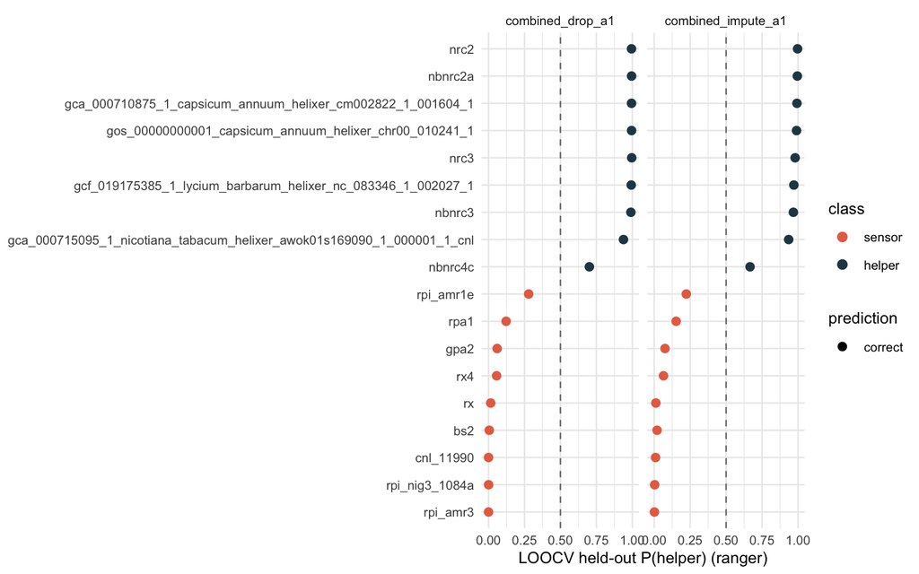

```r
ggplot(ho_all, aes(x = prob_helper, y = reorder(ID, prob_helper),
                   colour = class, shape = response == class)) +
  geom_vline(xintercept = 0.5, linetype = "dashed", colour = "grey50") +
  geom_point(size = 2.5) +
  facet_wrap(~ cell) +
  scale_colour_manual(values = c(sensor = "#e76f51", helper = "#264653")) +
  scale_shape_manual(values = c(`TRUE` = 16, `FALSE` = 4),
                     labels = c(`TRUE` = "correct", `FALSE` = "wrong"),
                     name = "prediction") +
  labs(x = "LOOCV held-out P(helper) (ranger)", y = NULL) +
  theme_minimal(base_size = 10)
```

They’re all re-predicted correctly and most $p(helper)$ stays appreciably away from the 0.5 zone of not being so sure.

## 5. Permutation null distribution

Class labels are permuted across the 18 proteins and the LOOCV pipeline is re-run on each shuffle. `n_perms = 200` shuffles per cell, ranger learner only (chosen for speed; the same approach applies to the other learners). Empirical one-sided p-values are `(1 + sum(null >= obs)) / (n_perms + 1)`.

Standard ‘bootstrap-like’ shuffling of labels for 200 reps. The idea being that we should see a nice aggregation of LOOCV accuracy (and AUC) around 0.5. Which would indicate that the random shuffling makes the model unable to recall the original labels. Randomly labelled models should not be classifiable, only those with real patterns in data should.

The result is cached to `results/permutation_results.rds`; delete that file to force recomputation.

```r
N_PERMS <- 200
PERM_CACHE <- here("results", "permutation_results.rds")

run_permutations <- function(data, features, lrn_id, impute,
                             n_perms, seed) {
  set.seed(seed)
  out <- matrix(NA_real_, nrow = n_perms, ncol = 2,
                dimnames = list(NULL, c("acc", "auc")))
  for (i in seq_len(n_perms)) {
    d_perm <- data
    d_perm$class <- sample(d_perm$class)
    res <- tryCatch(
      run_loocv(d_perm, features, lrn_id, impute),
      error = function(e) list(agg = c(classif.acc = NA_real_,
                                       classif.auc = NA_real_))
    )
    out[i, ] <- c(res$agg["classif.acc"], res$agg["classif.auc"])
  }
  as.data.frame(out)
}

if (file.exists(PERM_CACHE)) {
  perm_results <- readRDS(PERM_CACHE)
  message("Loaded cached permutation results from ", PERM_CACHE)
} else {
  message("Running ", N_PERMS, " permutations per cell (ranger)...")
  t0 <- Sys.time()
  perm_results <- lapply(seq_along(design), function(i) {
    cell <- design[[i]]
    obs <- run_loocv(mat_11, cell$features, "classif.ranger", cell$impute)$agg
    nulls <- run_permutations(mat_11, cell$features, "classif.ranger",
                              cell$impute, N_PERMS, seed = 100 + i)
    list(cell = cell$name, obs = obs, nulls = nulls)
  })
  names(perm_results) <- vapply(design, `[[`, character(1), "name")
  saveRDS(perm_results, PERM_CACHE)
  message("Done in ", round(as.numeric(difftime(Sys.time(), t0, units = "secs"))),
          " s")
}
```

```r
perm_summary <- do.call(rbind, lapply(perm_results, function(r) {
  data.frame(
    cell      = r$cell,
    obs_acc   = unname(r$obs["classif.acc"]),
    obs_auc   = unname(r$obs["classif.auc"]),
    null_acc_mean = mean(r$nulls$acc, na.rm = TRUE),
    null_auc_mean = mean(r$nulls$auc, na.rm = TRUE),
    p_acc     = (1 + sum(r$nulls$acc >= r$obs["classif.acc"], na.rm = TRUE)) /
                (sum(!is.na(r$nulls$acc)) + 1),
    p_auc     = (1 + sum(r$nulls$auc >= r$obs["classif.auc"], na.rm = TRUE)) /
                (sum(!is.na(r$nulls$auc)) + 1)
  )
}))
knitr::kable(perm_summary, digits = 3, row.names = FALSE)
```

| cell | obs_acc | obs_auc | null_acc_mean | null_auc_mean | p_acc | p_auc |
| --- | --- | --- | --- | --- | --- | --- |
| scientist_drop_a1 | 0.944 | 1.000 | 0.434 | 0.356 | 0.005 | 0.005 |
| scientist_impute_a1 | 0.944 | 1.000 | 0.443 | 0.374 | 0.005 | 0.005 |
| coscientist_drop_a1 | 0.889 | 0.877 | 0.446 | 0.399 | 0.005 | 0.010 |
| coscientist_impute_a1 | 0.833 | 0.951 | 0.454 | 0.408 | 0.015 | 0.005 |
| combined_drop_a1 | 1.000 | 1.000 | 0.436 | 0.356 | 0.005 | 0.005 |
| combined_impute_a1 | 1.000 | 1.000 | 0.432 | 0.364 | 0.005 | 0.005 |

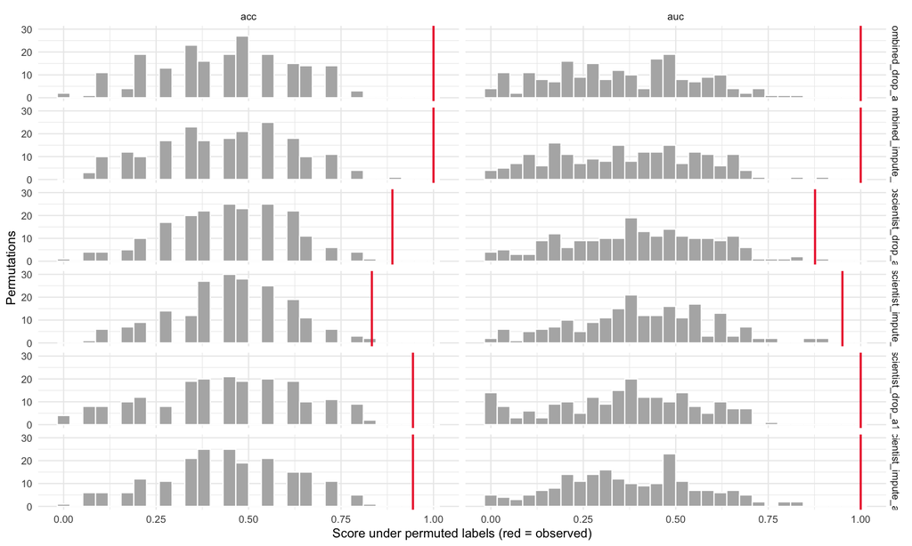

```r
nulls_long <- do.call(rbind, lapply(perm_results, function(r) {
  data.frame(cell = r$cell,
             metric = rep(c("acc", "auc"), each = nrow(r$nulls)),
             value  = c(r$nulls$acc, r$nulls$auc))
}))
obs_long <- do.call(rbind, lapply(perm_results, function(r) {
  data.frame(cell = r$cell,
             metric = c("acc", "auc"),
             value  = unname(c(r$obs["classif.acc"], r$obs["classif.auc"])))
}))

ggplot(nulls_long, aes(x = value)) +
  geom_histogram(bins = 30, fill = "grey70", colour = "white") +
  geom_vline(data = obs_long, aes(xintercept = value),
             colour = "#ED2939", linewidth = 0.8) +
  facet_grid(cell ~ metric, scales = "free_x") +
  labs(x = "Score under permuted labels (red = observed)", y = "Permutations") +
  theme_minimal(base_size = 10)
```

## 6. Conclusion

The combined data and `ranger` models give a great classification of sensors from helpers using the `SNI` features.